# Intro_coding_data_science

First get required modules

```python
import pandas
```

```python
pip install openpyxl
```

```python
pip install plotly
```

```python
import openpyxl
```

```python
import numpy
```

```python
import plotly.express as px
```

Now a simple example that creates a list object (vec) and uses a for loop to print the elements in the list

```python
vec = range(5)
```

```python
for val in vec:
    print(val)
```

```
0
1
2
3
4
```

This is an example of how to import data from an Excel .xlsx worksheet in the form of a data frame

```python
titanic = pandas.read_excel('titanic.xlsx',engine='openpyxl')
```

```python
titanic.head(5)
```

|  | PassengerId | Survived | Pclass | Name | Sex | Age | SibSp | Parch | Ticket | Fare | Cabin | Embarked |
| --- | --- | --- | --- | --- | --- | --- | --- | --- | --- | --- | --- | --- |
| 0 | 1 | 0 | 3 | Braund, Mr. Owen Harris | male | 22.0 | 1 | 0 | A/5 21171 | 7.2500 | NaN | S |
| 1 | 2 | 1 | 1 | Cumings, Mrs. John Bradley (Florence Briggs Th... | female | 38.0 | 1 | 0 | PC 17599 | 71.2833 | C85 | C |
| 2 | 3 | 1 | 3 | Heikkinen, Miss. Laina | female | 26.0 | 0 | 0 | STON/O2. 3101282 | 7.9250 | NaN | S |
| 3 | 4 | 1 | 1 | Futrelle, Mrs. Jacques Heath (Lily May Peel) | female | 35.0 | 1 | 0 | 113803 | 53.1000 | C123 | S |
| 4 | 5 | 0 | 3 | Allen, Mr. William Henry | male | 35.0 | 0 | 0 | 373450 | 8.0500 | NaN | S |

Now we can combine our data science with our programming and extract an element from the data frame, perform a task on it, and use it to plot results

Here we pull out the Age column and test whether values are greater or less than 30

```python
age = []
for val in titanic['Age']:
    age.append(val > 30)
print(age[0:5])
```

```
[False, True, False, True, True]
```

Note Trues and Falses (above) are useful but sometimes it's useful to have a list of 1s and zeros (for instance if you wanted to get the total number of values above 30)

```python
age = []
for val in titanic['Age']:
    age.append(int(val > 30))
print(age[0:5])
```

```
[0, 1, 0, 1, 1]
```

```python
sum(age)
```

```
305
```

Now we can use our test (over or under 30) to partition values from our original data frame and record stats of the partition and even do some plotting

```python
ageOver = []
ageUnder = []

for val in titanic['Age']:
    if val > 30:
        ageOver.append(val)
    else:
        ageUnder.append(val)
print(ageOver[0:5])
print(ageUnder[0:5])
print("Mean of data set 1 is % s" % (numpy.nanmean(ageOver)))
print("Mean of data set 1 is % s" % (numpy.nanmean(ageUnder)))
```

```
[38.0, 35.0, 35.0, 54.0, 58.0]
[22.0, 26.0, nan, 2.0, 27.0]
Mean of data set 1 is 42.927868852459014
Mean of data set 1 is 19.834156479217604
```

```python
df = pandas.DataFrame([['Old',42.9],['Young',19.8]])
df.columns = ['Class','Age']
df
```

|  | Class | Age |
| --- | --- | --- |
| 0 | Old | 42.9 |
| 1 | Young | 19.8 |

Obviously the average of the old and young are going to be different because we enforced the partitioning that way but this works as a nice validation that the partitioning was actually doing what we wanted it to

Now we can try out some plotting.

```python
fig = px.bar(df, x='Class', y='Age')
fig.show()
```

[interactive chart not shown]

Notice that in constructing the df dataframe displayed above we manually entered the values that we got from the output of our earlier test. That is a simple straightforward solution but it isn't automated so every time you changed something upstream you would have to change those values by hand, that's very error prone and inefficient. What we are going to do now is try out a few different ways of automating the plotting.

This gets advanced pretty quick but what this does is uses our 1's and 0's from the object "age" that we created in cell 12 and uses that to append a column "Class" that contains the values "Old" and "Young" onto our data frame object called "titanic". Notice this is very efficient because there are fewer random disconnected objects that we have to make (as opposed to doing the for loop with the if statements that creates ageOver and ageUnder in cell 19.

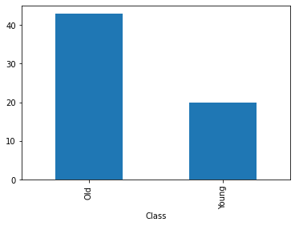

```python
titanic['Class'] = [ 'Old' if x == 1 else 'Young' for x in age ]
titanicg = titanic.groupby(['Class'])['Age'].mean()

titanicg.plot.bar(x='Class')
```

We can make this even cleaner (below) by using the test that was the basis of the earlier for loop and adding that in place of the test that converted the 0's and 1's from the object age to "Young" and "Old". This now completes the partitioning that we're interested in doing while leaving no straggling objects and the new column constructed "Class" is added straight into the source data frame so there is no ambiguity as to where it originated or what data frame it is in reference to.

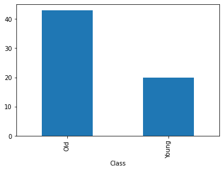

```python
titanic['Class'] = [ 'Old' if x > 30 else 'Young' for x in titanic['Age'] ]
titanicg = titanic.groupby(['Class'])['Age'].mean()

titanicg.plot.bar(x='Class')
```

Note in the above barplot we do still make an extra object "titanicg" with the means of the two classes that are then used to determine the heights of our barplots. We can instead use a different style of plotting that allows us to group the column "Age" by our column "Class" and thereby avoid creating the titanicg object. Note I'm using the boxyplot here because the pandas plotting command is most explicit about this possibility.

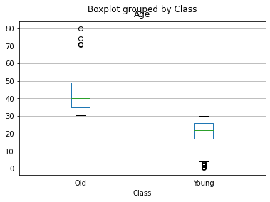

```python
pandas.plotting.boxplot(titanic,column='Age',by='Class')
```

Finally, we can simply use the pandas groupby which has similar functionality to the "by" argument used previously to avoid creating the index column (what we called "Class") altogether. This gives us the plot that we want without making any extraneous objects, external loops, or alterations to our original dataset. Also this was accomplished in a single line. Be warned that one-liners are effecient and good practice for all the reasons I just listed but they can be extremely non-intuitive for collaborators or reviewers who may be interested in your code.

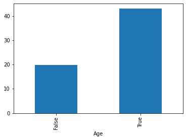

```python
titanic.groupby(titanic['Age']>30)['Age'].mean().plot.bar(x='Age')
```

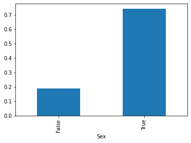

```python
titanic.groupby(titanic['Sex']=='female')['Survived'].mean().plot.bar(x='Survived')
```